# SQL PROJECT - SPATIAL DATA ANALYSIS WITH POSTGIS

Author

Duc Luong

Published

December 3, 2023

## 1 **Introduction**

**About this project:**

As I am new to spatial data analysis, this project will only focus on myself following the instructions and exercises provided by the [Introduction to PostGIS workshop](https://postgis.net/workshops/postgis-intro/index.html). With that said, I will attempt to come up with my own questions and scenarios to apply the newly acquired knowledge. This is an ongoing project and will be updated regularly until the workshop is completed.

**About the data:**

The data for this workshop is four shapefiles for New York City, and one attribute table of sociodemographic variables.

1. **nyc_census_blocks**

**More details**

| Column | Description |
| --- | --- |
| blkid | A 15-digit code that uniquely identifies every census block. Eg: 360050001009000 |
| popn_total | Total number of people in the census block |
| popn_white | Number of people self-identifying as “White” in the block |
| popn_black | Number of people self-identifying as “Black” in the block |
| popn_nativ | Number of people self-identifying as “Native American” in the block |
| popn_asian | Number of people self-identifying as “Asian” in the block |
| popn_other | Number of people self-identifying with other categories in the block |
| boroname | Name of the New York borough. Manhattan, The Bronx, Brooklyn, Staten Island, Queens |
| geom | Polygon boundary of the block |

2. **nyc_neighborhoods**

**More details**

| Column | Description |
| --- | --- |
| name | Name of the neighborhood |
| boroname | Name of the New York borough. Manhattan, The Bronx, Brooklyn, Staten Island, Queens |
| geom | Polygon boundary of the neighborhood |

3. **nyc_streets**

**More details**

| Column | Description |
| --- | --- |
| name | Name of the street |
| oneway | Is the street one-way? “yes” = yes, “” = no |
| type | Road type (primary, secondary, residential, motorway) |
| geom | Linear centerline of the street |

4. **nyc_subway_stations**

**More details**

| Column | Description |
| --- | --- |
| name | Name of the station |
| borough | Name of the New York borough. Manhattan, The Bronx, Brooklyn, Staten Island, Queens |
| routes | Subway lines that run through this station |
| transfers | Lines you can transfer to via this station |
| express | Stations where express trains stop, “express” = yes, “” = no |
| geom | Point location of the station |

5. **nyc_census_sociodata**

**More details**

| Column | Description |
| --- | --- |
| tractid | An 11-digit code that uniquely identifies every census tract. (“36005000100”) |
| transit_total | Number of workers in the tract |
| transit_private | Number of workers in the tract who use private automobiles / motorcycles |
| transit_public | Number of workers in the tract who take public transit |
| transit_walk | Number of workers in the tract who walk |
| transit_other | Number of workers in the tract who use other forms like walking / biking |
| transit_none | Number of workers in the tract who work from home |
| transit_time_mins | Total number of minutes spent in transit by all workers in the tract (minutes) |
| family_count | Number of families in the tract |
| family_income_median | Median family income in the tract (dollars) |
| family_income_mean | Average family income in the tract (dollars) |
| family_income_aggregate | Total income of all families in the tract (dollars) |
| edu_total | Number of people with educational history |
| edu_no_highschool_dipl | Number of people with no high school diploma |
| edu_highschool_dipl | Number of people with high school diploma and no further education |
| edu_college_dipl | Number of people with college diploma and no further education |
| edu_graduate_dipl | Number of people with graduate school diploma |

## 2 **Loading spatial data**

### 2.1 Creating a spatial database in PostgreSQL

Select the database. Load PostGIS spatial extension to the database in PgAdmin using the following query.

```sql
CREATE EXTENSION postgis;
```

Confim that PostGIS is installed

```sql
SELECT postgis_full_version();
```

### 2.2 Importing spatial data with OGR2OGR

Since I already have QGIS installed, I will import spatial data through OGR2OGR.

In OSGeo4W Shell, navigate to the folder containing data to import and type:

```powershell
ogr2ogr -nln nyc_census_blocks_2000 -nlt PROMOTE_TO_MULTI -lco GEOMETRY_NAME=geom -lco FID=gid -lco PRECISION=NO Pg:"dbname=nyc host=localhost user=postgres password=******** port=5432" nyc_census_blocks_2000.shp
```

Remember to change the `username` and `password`.

**Note**

Alternatively, data can be *restored* using `.backup` files in PgAdmin. To do so, right click on the database, then select **Restore…**

### 2.3 Trying to connect and view data with QGIS

Open QGIS, select **Layer > Add Layer > Add PostGIS Layers**

[figure not shown]

Click the **New** button, then fill out **Name** (nyc), **Host** (localhost), **Database** (nyc). Click **OK** to connect.

[figure not shown]

Once connected, select tables to add, then click **Add**.

[figure not shown]

Select layers to display from the **Layers** panel.

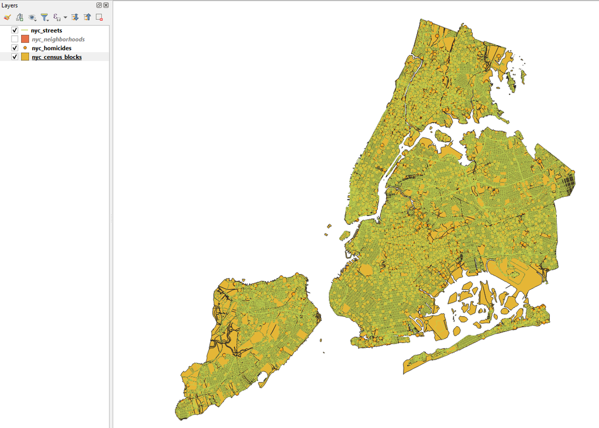

## 3 **Running non-spatial queries**

I will answer some questions about the datasets using SQL.

1. **How many records are there in the nyc_census_block?**

   ```sql
   SELECT COUNT(*)
   FROM nyc_census_blocks;
   ```

   Output:

   ```powershell
   "count"
   38794
   ```

2. **What is the total population of New York?**

   ```sql
   SELECT SUM(popn_total) AS total_population
   FROM nyc_census_blocks;
   ```

   Output:

   ```powershell
   "total_population"
   8175032
   ```

3. **What is the population of each borough of New York?**

   ```sql
   SELECT boroname, SUM(popn_total)
   FROM nyc_census_blocks
   GROUP BY boroname;
   ```

   Output:

   ```powershell
   | "boroname"      | "sum"   |
   |-----------------|---------|
   | "Queens"        | 2230621 |
   | "Brooklyn"      | 2504700 |
   | "The Bronx"     | 1385108 |
   | "Manhattan"     | 1585873 |
   | "Staten Island" | 468730  |
   ```

4. **Summarize demographic data from nyc_census_block table.**

   ```sql
   SELECT
     boroname,
     SUM(popn_total) AS total_pop,
     ROUND(((SUM(popn_white) / SUM(popn_total)) * 100)::numeric, 2) AS white_pop_pct,
     ROUND(((SUM(popn_black) / SUM(popn_total)) * 100)::numeric, 2) AS black_pop_pct,
     ROUND(((SUM(popn_asian) / SUM(popn_total)) * 100)::numeric, 2) AS asian_pop_pct,
     ROUND(((SUM(popn_nativ) / SUM(popn_total)) * 100)::numeric, 2) AS native_pop_pct,
     ROUND(((SUM(popn_other) / SUM(popn_total)) * 100)::numeric, 2) AS others_pop_pct
   FROM nyc_census_blocks
   GROUP BY boroname
   ORDER BY 2 DESC;
   ```

   Output:

   ```powershell
   | "boroname"      | "total_pop" | "white_pop_pct" | "black_pop_pct" | "asian_pop_pct" | "native_pop_pct" | "others_pop_pct" |
   |-----------------|-------------|-----------------|-----------------|-----------------|------------------|------------------|
   | "Brooklyn"      | 2504700     | 42.80           | 34.34           | 10.47           | 0.54             | 11.85            |
   | "Queens"        | 2230621     | 39.72           | 19.13           | 22.94           | 0.69             | 17.51            |
   | "Manhattan"     | 1585873     | 57.45           | 15.56           | 11.32           | 0.55             | 15.13            |
   | "The Bronx"     | 1385108     | 27.90           | 36.47           | 3.58            | 1.32             | 30.72            |
   | "Staten Island" | 468730      | 72.89           | 10.64           | 7.50            | 0.36             | 8.61             |
   ```

5. **How many subway stations are there in each borough in New York? Include a total number of stations to each row for comparison.**

   ```sql
   SELECT
     borough,
     (SELECT COUNT(*) FROM nyc_subway_stations) AS total_ny_stations,
     COUNT(name) AS stations_count
   FROM nyc_subway_stations
   GROUP BY borough;
   ```

   Output:

   ```powershell
   | "borough"       | "total_ny_stations" | "stations_count" |
   |-----------------|---------------------|------------------|
   | "Queens"        | 491                 | 90               |
   | "Brooklyn"      | 491                 | 170              |
   | "Staten Island" | 491                 | 22               |
   | "Manhattan"     | 491                 | 140              |
   | "Bronx"         | 491                 | 69               |
   ```

6. **Calculate the people per station metric for each borough.**

   ```sql
   -- Define a temporary table containing the number of stations per borough
   WITH stations_cte AS (
     SELECT
       borough,
       COUNT(*) AS total_stations,
       COUNT(CASE WHEN express = 'express' THEN 1 END) AS exp_stations
     FROM nyc_subway_stations
     GROUP BY borough
   )

   SELECT
     boroname,

     -- Calculate average population of New York
     AVG((SELECT SUM(popn_total) FROM nyc_census_blocks)) AS ny_populations,

     -- Calculate total population for each borough
     SUM(popn_total) AS boro_populations,

     -- Calculate average number of all stations per borough
     AVG(total_stations)::int AS stations_count,

     -- Calculate average people per all station
     ROUND(SUM(popn_total) / AVG(total_stations)) AS people_per_station,

     -- Calculate average number of express stations per borough
     AVG(exp_stations)::int AS express_stations_count,

     -- Calculate average people per express station (handle division by zero)
     ROUND(SUM(popn_total) / NULLIF(AVG(exp_stations), 0)) AS people_per_exp_station

   FROM nyc_census_blocks ncb
   LEFT JOIN stations_cte sc ON ncb.boroname = sc.borough
   GROUP BY boroname
   ORDER BY boro_populations DESC;
   ```

   Output:

   ```powershell
   | "boroname"      | "ny_populations" | "boro_populations" | "stations_count" | "people_per_station" | "express_stations_count" | "people_per_exp_station" |
   |-----------------|------------------|--------------------|------------------|----------------------|--------------------------|--------------------------|
   | "Brooklyn"      | 8175032          | 2504700            | 170              | 14734                | 31                       | 80797                    |
   | "Queens"        | 8175032          | 2230621            | 90               | 24785                | 14                       | 159330                   |
   | "Manhattan"     | 8175032          | 1585873            | 140              | 11328                | 62                       | 25579                    |
   | "The Bronx"     | 8175032          | 1385108            |                  |                      |                          |                          |
   | "Staten Island" | 8175032          | 468730             | 22               | 21306                | 0                        |                          |
   ```

## 4 **Running geometries functions**

Answer some questions about New York city streets using geometries functions.

1. **What is the total length of all streets in New York in kilometers?**

   ```sql
   SELECT ROUND(SUM(ST_Length(geom))::numeric / 1000, 2) AS total_length_km
   FROM nyc_streets;
   ```

   Output:

   ```powershell
   "total_length_km"
   10418.90
   ```

2. **How many types of streets are there and what is the total length of each type?**

   ```sql
   SELECT
     type,
     ROUND(SUM(ST_Length(geom))::numeric, 2) AS length_m
   FROM nyc_streets
   GROUP BY type
   ORDER BY length_m DESC;
   ```

   Output:

   ```powershell
   | "type"                                             | "length_m" |
   |----------------------------------------------------|------------|
   | "residential"                                      | 8629870.34 |
   | "motorway"                                         | 403622.48  |
   | "tertiary"                                         | 360394.88  |
   | "motorway_link"                                    | 294261.42  |
   | "secondary"                                        | 276264.30  |
   | "unclassified"                                     | 166936.37  |
   | "primary"                                          | 135034.23  |
   | "footway"                                          | 71798.49   |
   | "service"                                          | 28337.64   |
   | "trunk"                                            | 20353.58   |
   | "cycleway"                                         | 8863.75    |
   | "pedestrian"                                       | 4867.05    |
   | "construction"                                     | 4803.08    |
   | "residential; motorway_link"                       | 3661.58    |
   | "trunk_link"                                       | 3202.19    |
   | "primary_link"                                     | 2492.57    |
   | "living_street"                                    | 1894.64    |
   | "primary; residential; motorway_link; residential" | 1367.77    |
   | "undefined"                                        | 380.54     |
   | "steps"                                            | 282.75     |
   | "motorway_link; residential"                       | 215.08     |
   ```

3. **Calculate some summary statistics about New York streets.**

   ```sql
   SELECT
     ROUND(SUM(ST_Length(geom))) AS total_length_m,
     ROUND(AVG(ST_Length(geom))::numeric, 2) AS avg_length,
     ROUND(percentile_cont(.5)
         WITHIN GROUP (ORDER BY ST_Length(geom))::numeric, 2)
         AS median_length,
     ROUND(MAX(ST_Length(geom))) AS longest_length,
     (
       SELECT name
       FROM nyc_streets
       ORDER BY ST_Length(geom) DESC
       LIMIT 1
     ) AS longest_street
   FROM nyc_streets;
   ```

   Output:

   ```powershell
   | "total_length_m" | "avg_length" | "median_length" | "longest_length" | "longest_street"  |
   |------------------|--------------|-----------------|------------------|-------------------|
   | 10418905         | 545.75       | 269.11          | 14918            | "Leif Ericson Dr" |
   ```

4. **Find the named street of the northernmost point in New York.**

   Firstly, I need to find the northermost point in New York. The *northermost point* should be **a coordinate with the highest lattitude**. A street is a multilinestring type that contains multiple points. Therefore, my approach is to extract all points from all street geometries, then extract the lattitude and find the highest one. After the lattitude is found, I will find the name of the street by filtering street coordinates that contain this lattitude.
   - First query: find the highest lattitude of streets in New York.

   ```sql
   -- Dump all points from streets with non-null name.
   WITH dump_points_cte AS
     (SELECT ST_DumpPoints(geom) AS dp
     FROM nyc_streets
     WHERE name IS NOT NULL)

   -- Extract the highest lattitude point, i.e the northernmost point.
   SELECT ST_Y((dp).geom) AS lattitude
   FROM dump_points_cte
   ORDER BY 1 DESC
   LIMIT 1;
   ```

   Output:

   ```powershell
   "lattitude"
   4529895.358189691
   ```

   - Second query: filter the street name based on the lattitude found earlier.

   ```sql
   -- Find the non-null street that contains the highest lattitude point.
   SELECT name, ST_AsText(geom)
   FROM nyc_streets
   WHERE ST_AsText(geom) LIKE '%4529895.358189691%'
     AND name IS NOT NULL;
   ```

   Output:

   ```powershell
   | "name"     | "st_astext"                                                                                  |
   |------------|----------------------------------------------------------------------------------------------|
   | "River Rd" | "MULTILINESTRING((591838.3024050258 4529895.358189691,591831.6719192386 4529886.060201272))" |
   ```

   - Third query: transform one point of the linestring from SRID 26918 to SRID 4326 to find the coordinates on Google Maps.

   ```sql
   -- The WKT point coordinates are taken from one of the coordinates in the "st_astext" column.
   SELECT ST_AsText(ST_Transform(ST_GeomFromText('POINT(591838.3024050258 4529895.358189691)',26918),4326)) AS wgs_geom;
   ```

   Output:

   ```powershell
   "wgs_geom"
   "POINT(-73.90941589999974 40.91501400000343)"
   ```

   Reverse the order of the coordinates as **40.91501400000343 -73.90941589999974** (latitude, longitude), then search on Google Maps to double check.

[figure not shown]

The northernmost street of New York. Click the image to navigate to the exact coordinates on Google Maps.

## 5 **Spatial relationships**